# 03-Survival-analysis-regression-models

### 0.0.1 Quick tasks

Consider the `Melanoma` data set.

- Make Kaplan-Meier curves using the same `Surv` object defined above, i.e. with both censoring categories combined into a single one. Do this both for the entire data together, as well as for the observations according to gender.

```r
survm <- Surv(Melanoma$time, Melanoma$status == 1)
```

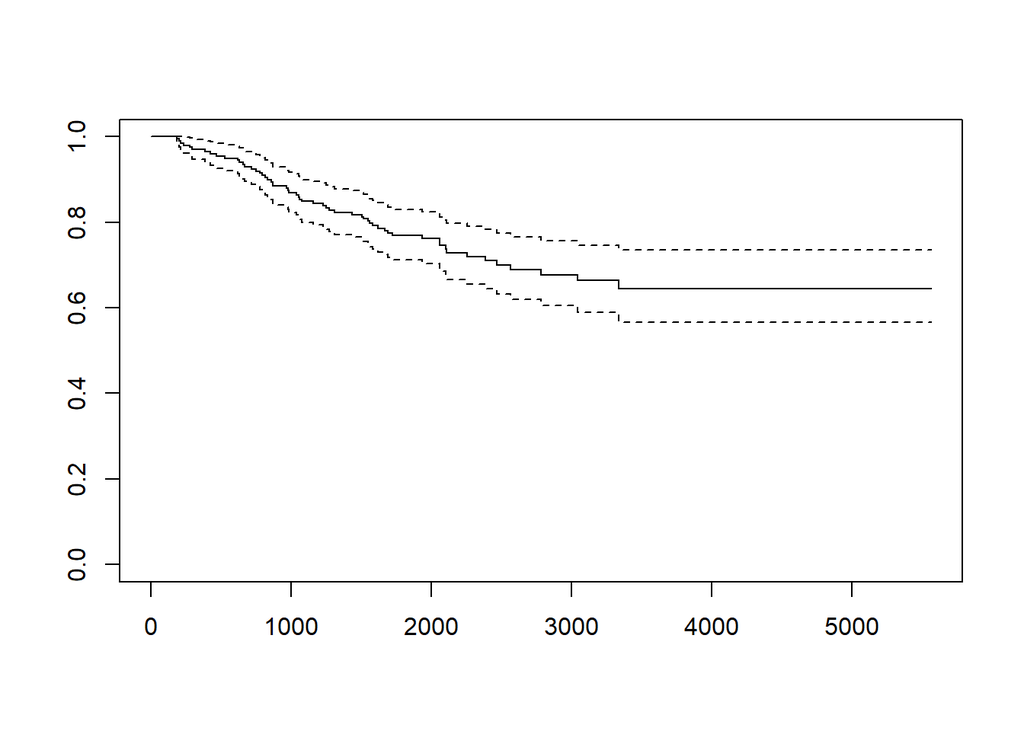

```r
plot(survfit(survm ~ 1))
```

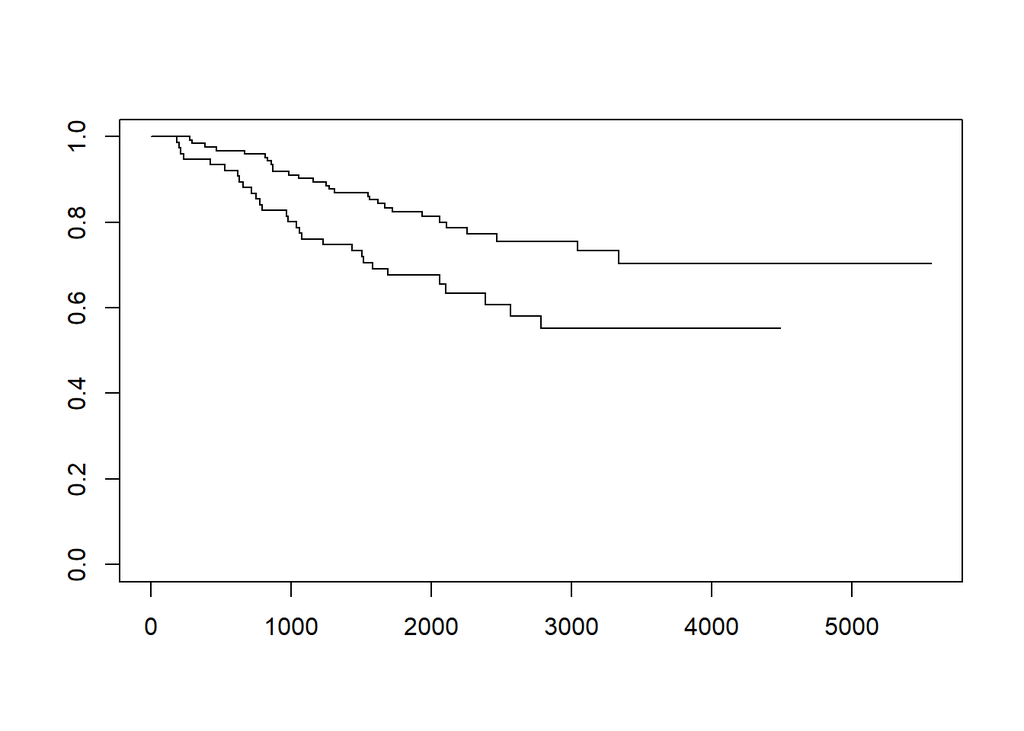

```r
plot(survfit(survm ~ Melanoma$sex))
```

- Compute the log-rank test to check whether there is evidence that the two survival probability curves are different.

```r
survdiff(survm ~ Melanoma$sex)
```

```
## Call:
## survdiff(formula = survm ~ Melanoma$sex)
##
##                  N Observed Expected (O-E)^2/E (O-E)^2/V
## Melanoma$sex=0 126       28     37.1      2.25      6.47
## Melanoma$sex=1  79       29     19.9      4.21      6.47
##
##  Chisq= 6.5  on 1 degrees of freedom, p= 0.01
```

Let us consider again the `leuk` example with overall survival data of leukemia cases, of the package `MASS`.

```r
library(MASS)
library(survival)
str(leuk)
```

```
## 'data.frame':    33 obs. of  3 variables:
##  $ wbc : int  2300 750 4300 2600 6000 10500 10000 17000 5400 7000 ...
##  $ ag  : Factor w/ 2 levels "absent","present": 2 2 2 2 2 2 2 2 2 2 ...
##  $ time: int  65 156 100 134 16 108 121 4 39 143 ...
```

We define again the response as a function of `time` only, since all patients experience an event (death). Subsequently, we fit a survival regression of the survival response as a function of `ag` and of white blood cell count `wbc`. We will use Cox regression for this.

- First, let us examine the nature of the relationship between `time` and the covariates `ag` and `wbc`. For this, we `log(time)` against each covariate. We are plotting `time` on the log-scale, as this is equivalent to what happens in the regression model.

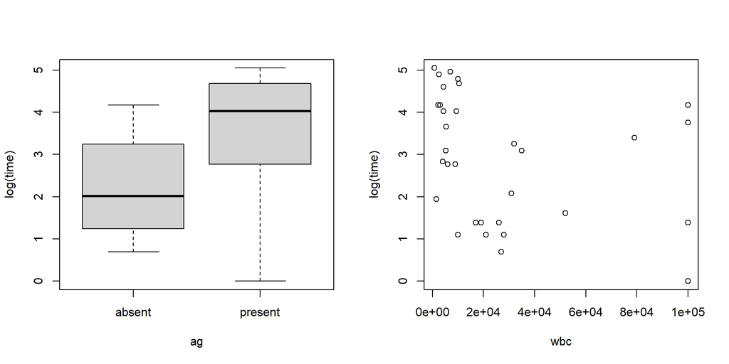

```r
par(mfrow = c(1, 2))
plot(log(time) ~ ag + wbc, data = leuk)
```

- The covariate `wbc` has many small values and only a few large ones. This is characteristic of a variable on an exponential scale. So let’s take its logarithm and make the plot again.

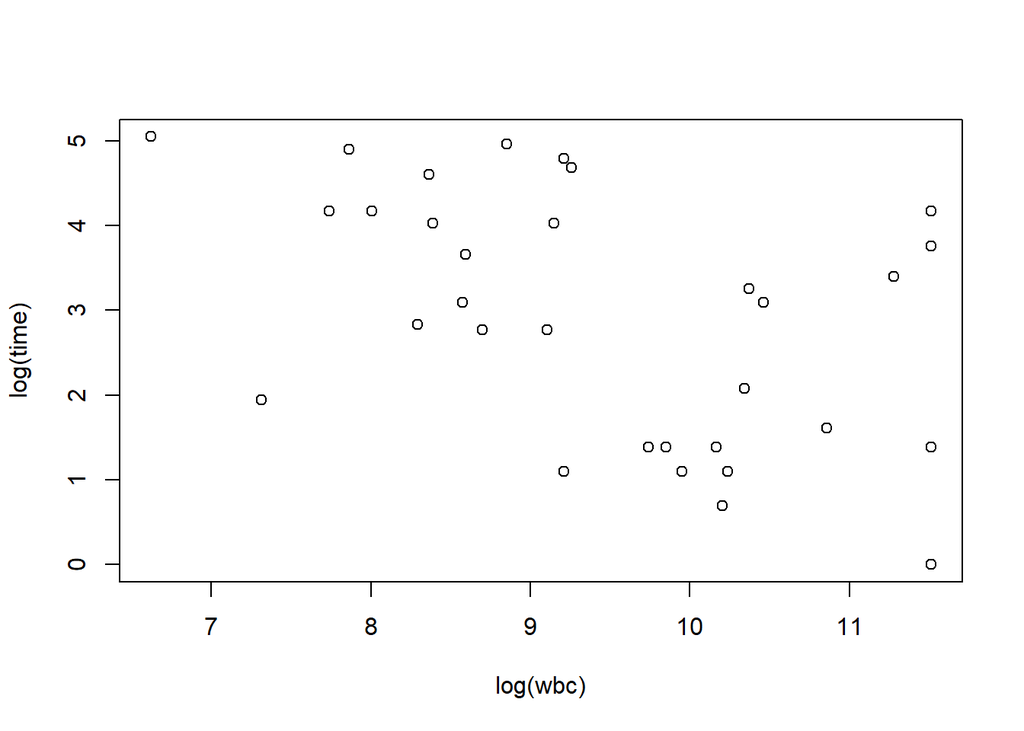

```
This relationship seems to be closer to linear. So, we will include `wbc` in the model with a log-transformation.
```

```r
plot(log(time) ~ log(wbc), data = leuk)
```

- Now let’s perform a Cox regression using the function `coxph()`.

  The `coxph()` function, like the regression functions `lm` and `glm`, expect a formula as input. The formula uses a `Surv` object as response on the left hand side, and the covariates on the right hand side (in this case `ag` and `log(wbc)`).

```r
leuk.cox <- coxph(Surv(time) ~ ag + log(wbc), data = leuk)
summary(leuk.cox)
```

```
## Call:
## coxph(formula = Surv(time) ~ ag + log(wbc), data = leuk)
##
##   n= 33, number of events= 33
##
##              coef exp(coef) se(coef)      z Pr(>|z|)
## agpresent -1.0691    0.3433   0.4293 -2.490  0.01276 *
## log(wbc)   0.3677    1.4444   0.1360  2.703  0.00687 **
## ---
## Signif. codes:  0 '***' 0.001 '**' 0.01 '*' 0.05 '.' 0.1 ' ' 1
##
##           exp(coef) exp(-coef) lower .95 upper .95
## agpresent    0.3433     2.9126     0.148    0.7964
## log(wbc)     1.4444     0.6923     1.106    1.8857
##
## Concordance= 0.726  (se = 0.047 )
## Likelihood ratio test= 15.64  on 2 df,   p=4e-04
## Wald test            = 15.06  on 2 df,   p=5e-04
## Score (logrank) test = 16.49  on 2 df,   p=3e-04
```

Consider again the Melanoma data, and now define `sex` as 1 for females and 0 for males.

- Fit the Cox regression model again and compare results with those when `sex` was used with the original coding.

```r
sex1 <- 1 - Melanoma$sex
mel.cox1 <- coxph(survm ~ sex1)
summary(mel.cox1)
```

```
## Call:
## coxph(formula = survm ~ sex1)
##
##   n= 205, number of events= 57
##
##         coef exp(coef) se(coef)      z Pr(>|z|)
## sex1 -0.6622    0.5157   0.2651 -2.498   0.0125 *
## ---
## Signif. codes:  0 '***' 0.001 '**' 0.01 '*' 0.05 '.' 0.1 ' ' 1
##
##      exp(coef) exp(-coef) lower .95 upper .95
## sex1    0.5157      1.939    0.3067    0.8672
##
## Concordance= 0.59  (se = 0.034 )
## Likelihood ratio test= 6.15  on 1 df,   p=0.01
## Wald test            = 6.24  on 1 df,   p=0.01
## Score (logrank) test = 6.47  on 1 df,   p=0.01
```

```r
# With the original coding we had:
mel.cox <- coxph(Surv(time, status == 1) ~ sex, data = Melanoma)
mel.cox
```

```
## Call:
## coxph(formula = Surv(time, status == 1) ~ sex, data = Melanoma)
##
##       coef exp(coef) se(coef)     z      p
## sex 0.6622    1.9390   0.2651 2.498 0.0125
##
## Likelihood ratio test=6.15  on 1 df, p=0.01314
## n= 205, number of events= 57
```